# Case Study 1: How does a bike-share navigate speedy success?

Bao Quoc Nguyen

2023-04-09

## Background

### Scenario

I am a junior data analyst working in the marketing analyst team at Cyclistic, a bike-share company in Chicago. The director of marketing believes the company’s future success depends on maximizing the number of annual memberships. Therefore, my team wants to understand how casual riders and annual members use Cyclistic bikes differently. From these insights, my team will design a new marketing strategy to convert casual riders into annual members.

### About the company

In 2016, Cyclistic launched a successful bike-share oering. Since then, the program has grown to a fleet of 5,824 bicycles that are geotracked and locked into a network of 692 stations across Chicago. The bikes can be unlocked from one station and returned to any other station in the system anytime. Until now, Cyclistic’s marketing strategy relied on building general awareness and appealing to broad consumer segments. One approach that helped make these things possible was the flexibility of its pricing plans: single-ride passes, full-day passes, and annual memberships. Customers who purchase single-ride or full-day passes are referred to as casual riders. Customers who purchase annual memberships are Cyclistic members. Cyclistic’s finance analysts have concluded that annual members are much more profitable than casual riders. Although the pricing flexibility helps Cyclistic attract more customers, The director of marketing believes that maximizing the number of annual members will be key to future growth. Rather than creating a marketing campaign that targets all-new customers, she believes there is a very good chance to convert casual riders into members. She notes that casual riders are already aware of the Cyclistic program and have chosen Cyclistic for their mobility needs.

## Ask

Three questions will guide the future marketing program:

1. How do annual members and casual riders use Cyclistic bikes differently?
2. Why would casual riders buy Cyclistic annual memberships?
3. How can Cyclistic use digital media to influence casual riders to become members?

In this assignment, I will produce a report with the following deliverables:

1. A clear statement of the business task
2. A description of all data sources used
3. Documentation of any cleaning or manipulation of data
4. A summary of my analysis
5. Supporting visualizations and key findings

## Prepare

About the data set:

Since Cyclistic is a fictional company, I will use Divvy’s, a bike-share program based in Chicago, data from March 2022 – March 2023 to complete this case study. This data was made public by Motivate International Inc, under this license. Due to data privacy issues, personal information has been removed or encrypted.

```r
library(Tmisc)
library(tidyverse)
library(pivottabler)
library(ggplot2)
library(tidyr)
library(geosphere)
```

Regarding the data, I will merge it into a single file only.

```r
df1 <- list.files(path = "/Users/quocbaonguyen/Downloads/Raw data/untitled folder", pattern = "*.csv", full.names = TRUE) %>%
  lapply(read_csv) %>%
  bind_rows()
```

## Process

```r
glimpse(df1)
```

```
## Rows: 5,829,084
## Columns: 13
## $ ride_id            <chr> "47EC0A7F82E65D52", "8494861979B0F477", "EFE527AF80~
## $ rideable_type      <chr> "classic_bike", "electric_bike", "classic_bike", "c~
## $ started_at         <dttm> 2022-03-21 13:45:01, 2022-03-16 09:37:16, 2022-03-~
## $ ended_at           <dttm> 2022-03-21 13:51:18, 2022-03-16 09:43:34, 2022-03-~
## $ start_station_name <chr> "Wabash Ave & Wacker Pl", "Michigan Ave & Oak St", ~
## $ start_station_id   <chr> "TA1307000131", "13042", "13109", "TA1307000131", "~
## $ end_station_name   <chr> "Kingsbury St & Kinzie St", "Orleans St & Chestnut ~
## $ end_station_id     <chr> "KA1503000043", "620", "15578", "TA1305000025", "13~
## $ start_lat          <dbl> 41.88688, 41.90100, 41.97835, 41.88688, 41.91172, 4~
## $ start_lng          <dbl> -87.62603, -87.62375, -87.65975, -87.62603, -87.626~
## $ end_lat            <dbl> 41.88918, 41.89820, 41.98404, 41.87771, 41.87794, 4~
## $ end_lng            <dbl> -87.63851, -87.63754, -87.66027, -87.63532, -87.662~
## $ member_casual      <chr> "member", "member", "member", "member", "member", "~
```

#### Findings:

- There doesn’t seem to be any problem here, as all fields appear to have the correct format.

### 2. Check for the data

```r
empty_cols <- colSums(is.na(df1))
empty_cols[empty_cols > 0] #NA check
```

```
## start_station_name   start_station_id   end_station_name     end_station_id
##             850418             850550             909038             909179
##            end_lat            end_lng
##               5938               5938
```

#### Findings:

- Although having empty values, it should not be a big problem for our analysis.
- However, we need to be mindful and take into account any potential bias or limitations that may arise from the missing data when interpreting the results.

### 3. Create some fields for further analysis

For further analysis, I want to create the duration field.

```r
#Trip duration
df1$durat <- df1$ended_at - df1$started_at
df1$durat <- as.numeric(df1$durat) #change to numberic format for some calculations
```

### 4. Check for the data after creating the duration field

Since we have the duration field, let’s check if there are any negative values or not.

```r
head(df1 %>%
  filter(durat < 0))
```

```
## # A tibble: 6 x 14
##   ride_id        ridea~1 started_at          ended_at            start~2 start~3
##   <chr>          <chr>   <dttm>              <dttm>              <chr>   <chr>
## 1 2D97E3C98E165~ classi~ 2022-03-05 11:00:57 2022-03-05 10:55:01 DuSabl~ TA1307~
## 2 7407049C5D89A~ electr~ 2022-03-05 11:38:04 2022-03-05 11:37:57 Sheffi~ TA1307~
## 3 0793C9208A643~ electr~ 2022-05-30 11:06:29 2022-05-30 11:06:17 Broadw~ 13325
## 4 B897BE02B21FA~ electr~ 2022-06-07 19:15:39 2022-06-07 17:05:37 <NA>    <NA>
## 5 072E947E156D1~ electr~ 2022-06-07 19:14:46 2022-06-07 17:07:45 W Armi~ 20254.0
## 6 6A871510E302E~ electr~ 2022-06-23 19:22:57 2022-06-23 19:21:46 <NA>    <NA>
## # ... with 8 more variables: end_station_name <chr>, end_station_id <chr>,
## #   start_lat <dbl>, start_lng <dbl>, end_lat <dbl>, end_lng <dbl>,
## #   member_casual <chr>, durat <dbl>, and abbreviated variable names
## #   1: rideable_type, 2: start_station_name, 3: start_station_id
```

#### Findings:

I have found that there are numerous negative values in the dataset, which is highly unreasonable. To prevent these outliers from affecting our analysis, I will filter them out.

```r
df2 <- df1 %>% filter(!(df1$durat < 0))
```

### 5. Keep creating some fields for further analysis

```r
#Weekdate
df2$weekday <- weekdays(
  df2$started_at,
  abbreviate = TRUE
)

# Date
df2$date <- format(
  as.Date(
    df2$started_at,
    format = "%d/%m/%Y"
  ), "%d"
)

# Month
df2$month <- format(
  as.Date(
    df2$started_at,
    format = "%d/%m/%Y"
  ), "%m"
)

# Year
df2$year <- format(
  as.Date(
    df2$started_at,
    format = "%d/%m/%Y"
  ), "%Y"
)

#Distance between the start point and end point

dist_haversine <- function(lat1, lon1, lat2, lon2) {
  distHaversine(c(lon1, lat1), c(lon2, lat2)) / 1000 # Convert from m to km
}
df2$distance <- mapply(dist_haversine, df2$start_lat, df2$start_lng, df2$end_lat, df2$end_lng)
```

### 6. Others

I have also created a variable in the dataset that represents the distance between stations, which may be useful for further analysis.

```r
station_distance <- df2 %>%
  select(start_station_name, end_station_name, distance) %>%
  filter(!is.na(start_station_name) & !is.na(end_station_name) & !is.na(distance)) %>%
  filter(!(start_station_name == end_station_name)) %>%
  group_by(start_station_name, end_station_name) %>%
  summarize(mean_distance = mean(distance))
```

```r
df6_station_rideid <- df2 %>% #number of ride by route
  select(member_casual, start_station_name, ride_id, end_station_name) %>%
  filter(!is.na(start_station_name) & !is.na(end_station_name)) %>%
  pivot_longer(cols = -c(start_station_name, member_casual, end_station_name), names_to = "member_casuals", values_to = "descr") %>%
  group_by(start_station_name, member_casual, end_station_name) %>%
  summarise(n = n()) %>%
  pivot_wider(names_from = member_casual, values_from = n, values_fill = 0)

df6_station_duration <- df2 %>% #average duration of ride by route
  select(member_casual, start_station_name, end_station_name, durat) %>%
  filter(!is.na(start_station_name) & !is.na(end_station_name)) %>%
  pivot_longer(cols = c(-start_station_name, -end_station_name, -member_casual), names_to = "variable", values_to = "sum") %>%
  group_by(start_station_name, member_casual, end_station_name) %>%
  summarise(sum = sum(sum), .groups = "drop") %>%
  pivot_wider(names_from = member_casual, values_from = sum, values_fill = 0)

df6_merged_df_member_station_full <- left_join(df6_station_rideid, df6_station_duration, by = c("start_station_name", "end_station_name"))
colnames(df6_merged_df_member_station_full) <- c("start", "end", "num_c_rideid", "num_m_rideid", "sum_c_durat", "sum_m_durat")

df6_casual_number_durat <- select(df6_merged_df_member_station_full, -c("num_m_rideid", "sum_m_durat")) #information about the casual only, use this to analyze

df6_casual_number_durat <- df6_casual_number_durat %>% #By calculating the multiple field, we can identify the most popular routes in terms of the number of rides and their durations, which will ultimately help us increase our profits
  mutate(multiple = num_c_rideid * sum_c_durat)

# Based on the 80/20 rule, filter out top 20% of top popular route

df6_casual_number_durat_80 <- df6_casual_number_durat %>%
  filter(multiple >= quantile(df6_casual_number_durat$multiple, 0.8)) %>%
  arrange(desc(multiple))
```

## Analyze and Share

### 1. Statistics description by member_casual

```r
df3_stat <- df2 %>%
  group_by(member_casual) %>%
  summarize(
    n(),
    mean = mean(durat),
    max = max(durat),
    min = min(durat),
    sd = sd(durat),
    med = median(durat)
  )
```

#### Findings:

- Casual users tend to ride less frequently but for longer durations compared to member users. This would indicate a more leisure oriented usage vs a more “public transport” or pragmatic use of the bikes by the member users

### 2. Statistics description by member_casual per weekday and month

#### Consider in weekday

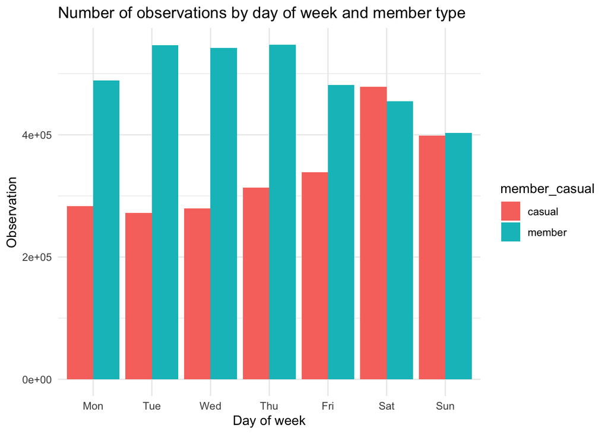

```r
df4_stat_bydatweekday <- df2 %>%
  group_by(weekday, member_casual) %>%
  summarize(
    n = n(),
    mean = mean(durat),
    max = max(durat),
    min = min(durat),
    sd = sd(durat),
    med = median(durat)
  ) %>%
  arrange(match(weekday, c("Mon", "Tue", "Wed", "Thu", "Fri", "Sat", "Sun")))

ggplot(df4_stat_bydatweekday) +
  geom_col(aes(x = weekday, y = n, fill = member_casual), position = "dodge") +
  labs(
    title = "Number of observations by day of week and member type",
    x = "Day of week",
    y = "Observation"
  ) +
  scale_x_discrete(limits = c("Mon", "Tue", "Wed", "Thu", "Fri", "Sat", "Sun")) +
  theme_minimal()
```

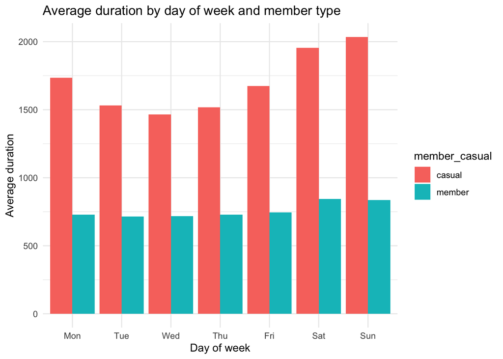

```r
ggplot(df4_stat_bydatweekday) +
  geom_col(aes(x = weekday, y = mean, fill = member_casual), position = "dodge") +
  labs(
    title = "Average duration by day of week and member type",
    x = "Day of week",
    y = "Average duration"
  ) +
  scale_x_discrete(limits = c("Mon", "Tue", "Wed", "Thu", "Fri", "Sat", "Sun")) +
  theme_minimal()
```

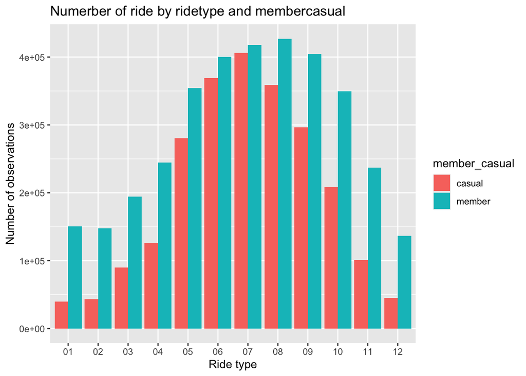

```r
df4_stat_bymonth <- df2 %>%
  group_by(month, member_casual) %>%
  summarize(
    n = n(),
    mean = mean(durat),
    max = max(durat),
    min = min(durat),
    sd = sd(durat),
    med = median(durat)
  )

ggplot(df4_stat_bymonth) +
  geom_col(aes(x = month, y = n, fill = member_casual), position = "dodge") +
  labs(
    title = "Numerber of ride by ridetype and membercasual",
    x = "Ride type",
    y = "Number of observations"
  )
```

#### Findings:

- Casual users tend to ride more times and longer hours on Saturday and Sunday. Maybe they just spend their weekend renting a bike to go sightseeing.
- There is a significant increase in the number of bike users and the duration of bike rides during the months of June, July, and August, indicating a high peak in bike usage during this period

### 3. Statistics description by ridetype

```r
df5_stat_byridetype <- df2 %>%
  group_by(rideable_type, member_casual) %>%
  summarize(
    n = n(),
    mean = mean(durat),
    max = max(durat),
    min = min(durat),
    sd = sd(durat),
    med = median(durat)
  )
```

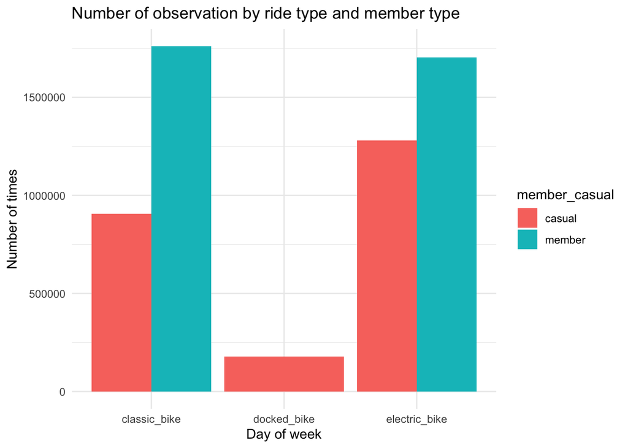

```r
ggplot(df5_stat_byridetype) +
  geom_col(aes(x = rideable_type, y = n, fill = member_casual), position = "dodge") +
  labs(
    title = "Number of observation by ride type and member type",
    x = "Day of week",
    y = "Number of times"
  ) +
  theme_minimal()
```

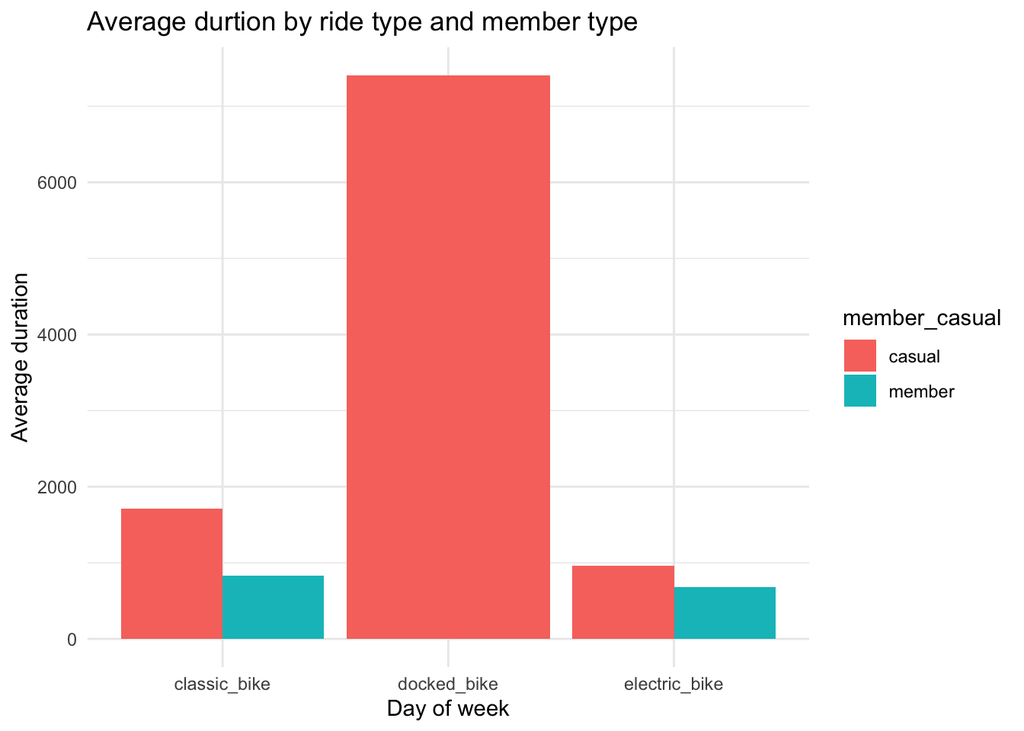

```r
ggplot(df5_stat_byridetype) +
  geom_col(aes(x = rideable_type, y = mean, fill = member_casual), position = "dodge") +
  labs(
    title = "Average durtion by ride type and member type",
    x = "Day of week",
    y = "Average duration"
  ) +
  theme_minimal()
```

```r
df5_stat_byridetype_distance <- df2 %>%
  filter(!is.na(df2$distance)) %>%
  group_by(rideable_type, member_casual) %>%
  summarize(
    n = n(),
    mean = mean(distance),
    max = max(distance),
    min = min(distance),
    sd = sd(distance),
    med = median(distance)
  )
```

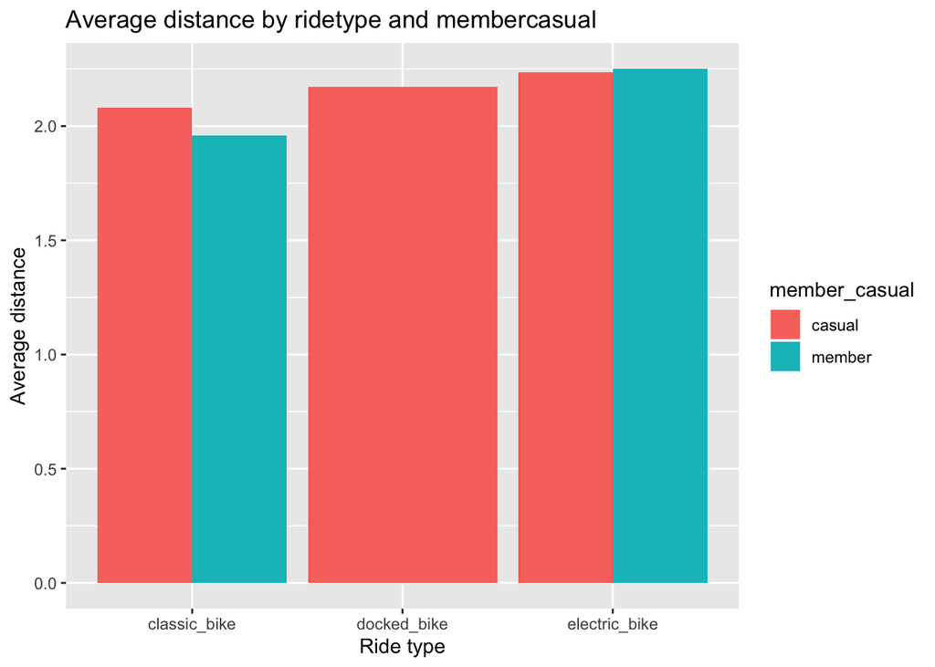

```r
ggplot(df5_stat_byridetype_distance) +
  geom_col(aes(x = rideable_type, y = mean, fill = member_casual), position = "dodge") +
  labs(
    title = "Average distance by ridetype and membercasual",
    x = "Ride type",
    y = "Average distance"
  )
```

#### Findings:

- There are no significant differences between the station distance regarding the ride type and member/casual. However, we can see one interesting thing which is only casual members use the docked bike and the duration of docked is the highest among the ridetype.

### 4. Statistics description by the route

The routes can be divided into two groups - the first group consists of routes where the start station and end station are the same, while the second group consists of all other routes

```r
df6_1st_group <- df6_casual_number_durat_80 %>% #1st group
  filter(start == end) %>%
  arrange(desc(multiple))
df6_startisend_ridetype_distance <- df2 %>% #adding the ridetype information
  select(start_station_name, end_station_name, rideable_type, ride_id) %>%
  filter(start_station_name == end_station_name) %>%
  pivot_longer(cols = -c(start_station_name, end_station_name, rideable_type), names_to = "member_casuals", values_to = "descr") %>%
  group_by(start_station_name, end_station_name, rideable_type) %>%
  summarise(n = n()) %>%
  pivot_wider(names_from = rideable_type, values_from = n, values_fill = 0)
```

```
## You can override using the `.groups` argument.
```

```r
colnames(df6_startisend_ridetype_distance) <- c("start", "end", "electric_bike", "classic_bike", "docked_bike")
df6_1st_group_final <- left_join(df6_1st_group, df6_startisend_ridetype_distance, by = c("start", "end"))
summary(df6_1st_group_final)
```

```
##     start               end             num_c_rideid       sum_c_durat
##  Length:824         Length:824         Min.   :    6.00   Min.   :    3944
##  Class :character   Class :character   1st Qu.:   34.75   1st Qu.:   52508
##  Mode  :character   Mode  :character   Median :   85.00   Median :  162370
##                                        Mean   :  214.77   Mean   :  458123
##                                        3rd Qu.:  207.25   3rd Qu.:  381376
##                                        Max.   :10712.00   Max.   :26054865
##     multiple         electric_bike      classic_bike      docked_bike
##  Min.   :1.110e+05   Min.   :   0.00   Min.   :   0.00   Min.   :   0.00
##  1st Qu.:1.792e+06   1st Qu.:  25.75   1st Qu.:  15.75   1st Qu.:   2.00
##  Median :1.367e+07   Median :  77.00   Median :  80.50   Median :  10.00
##  Mean   :8.458e+08   Mean   : 131.17   Mean   : 194.09   Mean   :  38.41
##  3rd Qu.:7.388e+07   3rd Qu.: 175.25   3rd Qu.: 245.50   3rd Qu.:  27.00
##  Max.   :2.791e+11   Max.   :2972.00   Max.   :6902.00   Max.   :2412.00
```

```r
df6_2nd_group <- df6_casual_number_durat_80 %>% #2nd group
  filter(!(start == end)) %>%
  arrange(desc(multiple))
df6_startnotend_ridetype_distance <- df2 %>%
  select(start_station_name, end_station_name, rideable_type, ride_id) %>%
  filter(!(start_station_name == end_station_name)) %>%
  pivot_longer(cols = -c(start_station_name, end_station_name, rideable_type), names_to = "member_casuals", values_to = "descr") %>%
  group_by(start_station_name, end_station_name, rideable_type) %>%
  summarise(n = n()) %>%
  pivot_wider(names_from = rideable_type, values_from = n, values_fill = 0)
```

```
## You can override using the `.groups` argument.
```

```r
colnames(df6_startnotend_ridetype_distance) <- c("start", "end", "electric_bike", "classic_bike", "docked_bike")
df6_2nd_group_final <- left_join(df6_2nd_group, df6_startnotend_ridetype_distance, by = c("start", "end"))
summary(df6_2nd_group_final)
```

```
##     start               end             num_c_rideid      sum_c_durat
##  Length:34378       Length:34378       Min.   :   1.00   Min.   :   5041
##  Class :character   Class :character   1st Qu.:  13.00   1st Qu.:  16531
##  Mode  :character   Mode  :character   Median :  22.00   Median :  26435
##                                        Mean   :  38.77   Mean   :  50604
##                                        3rd Qu.:  42.00   3rd Qu.:  49048
##                                        Max.   :5137.00   Max.   :8569003
##     multiple         electric_bike      classic_bike     docked_bike
##  Min.   :1.100e+05   Min.   :   0.00   Min.   :   0.0   Min.   :   0.000
##  1st Qu.:2.261e+05   1st Qu.:  10.00   1st Qu.:  15.0   1st Qu.:   0.000
##  Median :5.418e+05   Median :  19.00   Median :  31.0   Median :   1.000
##  Mean   :1.044e+07   Mean   :  32.63   Mean   :  59.1   Mean   :   3.627
##  3rd Qu.:1.814e+06   3rd Qu.:  39.00   3rd Qu.:  66.0   3rd Qu.:   3.000
##  Max.   :4.402e+10   Max.   :1398.00   Max.   :6406.0   Max.   :1287.000
```

#### Findings:

- Based on the multiple index, we have identified the characteristics of routes with high multiples. From this, we can provide some suggestions.

## Suggestions

- To increase ridership, we can launch a weekend and peak season (June, July, August) campaign to target more casual users.
- We can also explore partnerships with third-party organizations to attract more docked bike users, such as collaborating with tourism agencies to provide free route recommendations to our members.
- Based on our route analysis, we can focus on launching campaigns at specific stations to attract more casual members.